# Predicting Earthquake Damage: A Case Study in Nepal

## Executive Summary

Following the devastating 2015 Gorkha earthquake in Nepal, a critical need emerged for data-driven approaches to understand building vulnerability and guide reconstruction efforts. This project addresses this need by developing machine learning models to predict the level of damage to buildings, with a focus on the Gorkha district, the earthquake's epicenter.

Our analysis began by consolidating data from multiple sources, including building structures, damage assessments, and household demographics, extracted from a comprehensive SQLite database. We then engineered a binary classification problem to predict whether a building suffered 'severe damage' (damage grade 4 or 5) or not.

## 1. Introduction

The 2015 Gorkha earthquake in Nepal was a catastrophic event that resulted in widespread destruction and loss of life. In the aftermath, a massive international effort was launched to survey the damage and support rebuilding. This project leverages the resulting dataset to build predictive models that can identify buildings most at risk of severe damage in future seismic events.

Our primary objectives are:

- To build and evaluate classification models that predict severe building damage based on structural and demographic features.
- To identify the most significant predictors of earthquake damage.
- To conduct an ethical analysis to determine if certain demographic groups are disproportionately affected, ensuring that data-driven solutions do not perpetuate existing inequalities.

This report will walk through the process of data acquisition via SQL, exploratory analysis, model development (Logistic Regression and Decision Trees), and a critical examination of the ethical implications of our findings.

```python
!pip install "prettytable<3.0" --force-reinstall
```

[output not shown]

```python
import sqlite3
import warnings

import matplotlib.pyplot as plt
import numpy as np
import pandas as pd
import seaborn as sns
from category_encoders import OneHotEncoder, OrdinalEncoder
from sklearn.linear_model import LogisticRegression
from sklearn.metrics import accuracy_score
from sklearn.model_selection import train_test_split
from sklearn.pipeline import Pipeline, make_pipeline
from sklearn.tree import DecisionTreeClassifier, plot_tree
from sklearn.utils.validation import check_is_fitted

warnings.simplefilter(action="ignore", category=FutureWarning)
```

## 2. Data Acquisition and Preparation

The dataset for this project is stored in an SQLite database, a self-contained, serverless database engine. Our first step is to connect to this database and extract the relevant information using SQL queries. The data is spread across multiple tables, which we will need to join together to create a unified dataset for our analysis.

```python
%load_ext sql
%sql sqlite:///nepal.sqlite
```

### 2.1. Database Exploration

To understand the database structure, we first inspect the `sqlite_schema` table. This meta-table contains information about all other tables, views, and indexes within the database.

```python
%%sql
SELECT * FROM sqlite_schema
```

```
 * sqlite:///nepal.sqlite
Done.
```

| type | name | tbl_name | rootpage | sql |
| --- | --- | --- | --- | --- |
| table | id_map | id_map | 2 | CREATE TABLE "id_map" ( "household_id" INTEGER, "building_id" INTEGER, "vdcmun_id" INTEGER, "district_id" INTEGER ) |
| index | ix_id_map_household_id | id_map | 3 | CREATE INDEX "ix_id_map_household_id"ON "id_map" ("household_id") |
| table | building_structure | building_structure | 2032 | CREATE TABLE "building_structure" ( "building_id" INTEGER, "count_floors_pre_eq" INTEGER, "count_floors_post_eq" INTEGER, "age_building" INTEGER, "plinth_area_sq_ft" INTEGER, "height_ft_pre_eq" INTEGE… |
| index | ix_building_structure_building_id | building_structure | 2033 | CREATE INDEX "ix_building_structure_building_id"ON "building_structure" ("building_id") |
| table | building_damage | building_damage | 12302 | CREATE TABLE "building_damage" ( "building_id" INTEGER, "damage_overall_collapse" TEXT, "damage_overall_leaning" TEXT, "damage_overall_adjacent_building_risk" TEXT, "damage_foundation_severe" TEXT, "d… |
| index | ix_building_damage_building_id | building_damage | 12305 | CREATE INDEX "ix_building_damage_building_id"ON "building_damage" ("building_id") |
| table | household_demographics | household_demographics | 30763 | CREATE TABLE "household_demographics" ( "household_id" INTEGER, "gender_household_head" TEXT, "age_household_head" REAL, "caste_household" TEXT, "education_level_household_head" TEXT, "income_level_ho… |
| index | ix_household_demographics_household_id | household_demographics | 30764 | CREATE INDEX "ix_household_demographics_household_id"ON "household_demographics" ("household_id") |

The schema reveals several tables of interest: `id_map`, `building_structure`, `building_damage`, and `household_demographics`. These tables are linked by common identifiers like `building_id` and `household_id`. Our next step is to combine them into a single, cohesive dataset focused on the Gorkha district (district ID `4`).

```python
%%sql
SELECT
    h.*,
    i.vdcmun_id ,
    s.*,
    d.damage_grade
FROM household_demographics AS h
JOIN id_map AS i ON i.household_id = h.household_id
JOIN building_structure AS s ON i.building_id = s.building_id
JOIN building_damage AS d ON i.building_id = d.building_id
WHERE district_id = 4
LIMIT 5
```

```
 * sqlite:///nepal.sqlite
Done.
```

| household_id | gender_household_head | age_household_head | caste_household | education_level_household_head | income_level_household | size_household | is_bank_account_present_in_household | vdcmun_id | building_id | count_floors_pre_eq | count_floors_post_eq | age_building | plinth_area_sq_ft | height_ft_pre_eq | height_ft_post_eq | land_surface_condition | foundation_type | roof_type | ground_floor_type | other_floor_type | position | plan_configuration | condition_post_eq | superstructure | damage_grade |
| --- | --- | --- | --- | --- | --- | --- | --- | --- | --- | --- | --- | --- | --- | --- | --- | --- | --- | --- | --- | --- | --- | --- | --- | --- | --- |
| 16400201 | Female | 46.0 | Chhetree | Class 5 | Rs. 10-20 thousand | 4.0 | 1.0 | 38 | 164002 | 3 | 3 | 20 | 560 | 18 | 18 | Flat | Mud mortar-Stone/Brick | Bamboo/Timber-Light roof | Mud | TImber/Bamboo-Mud | Not attached | Rectangular | Damaged-Repaired and used | Stone, mud mortar | Grade 2 |
| 16408101 | Male | 66.0 | Chhetree | Illiterate | Rs. 10 thousand | 5.0 | 0.0 | 38 | 164081 | 2 | 2 | 21 | 200 | 12 | 12 | Flat | Mud mortar-Stone/Brick | Bamboo/Timber-Light roof | Mud | TImber/Bamboo-Mud | Not attached | Rectangular | Damaged-Used in risk | Stone, mud mortar | Grade 2 |
| 16408901 | Male | 54.0 | Magar | Class 4 | Rs. 10 thousand | 5.0 | 1.0 | 38 | 164089 | 3 | 3 | 18 | 315 | 20 | 20 | Flat | Mud mortar-Stone/Brick | Bamboo/Timber-Light roof | Mud | TImber/Bamboo-Mud | Not attached | Rectangular | Damaged-Used in risk | Stone, mud mortar | Grade 2 |
| 16409801 | Male | 36.0 | Chhetree | Class 5 | Rs. 10 thousand | 6.0 | 1.0 | 38 | 164098 | 2 | 2 | 45 | 290 | 13 | 13 | Flat | Mud mortar-Stone/Brick | Bamboo/Timber-Light roof | Mud | TImber/Bamboo-Mud | Not attached | Rectangular | Damaged-Used in risk | Stone, mud mortar | Grade 3 |
| 16410301 | Female | 39.0 | Chhetree | Class 4 | Rs. 10 thousand | 3.0 | 0.0 | 38 | 164103 | 2 | 2 | 21 | 230 | 13 | 13 | Flat | Mud mortar-Stone/Brick | Bamboo/Timber-Light roof | Mud | TImber/Bamboo-Mud | Not attached | Rectangular | Damaged-Used in risk | Stone, mud mortar | Grade 3 |

### 2.2. Data Wrangling Function

To ensure reproducibility and streamline the data preparation process, we encapsulate all cleaning and transformation steps into a single `wrangle` function. This function performs the following actions:

1. **Connects** to the SQLite database.
2. **Executes** a SQL query to join the `household_demographics`, `id_map`, `building_structure`, and `building_damage` tables for the Gorkha district.
3. **Transforms** the multi-class `damage_grade` target into a binary `severe_damage` target (1 for grades 4-5, 0 otherwise).
4. **Removes** leaky features (data collected post-earthquake), redundant IDs, and features causing high multicollinearity.
5. **Manages** the high-cardinality `caste_household` feature by grouping less frequent categories into an 'Other' category.
6. **Returns** a clean, analysis-ready pandas DataFrame.

```python
def wrangle(db_path):
    # Connect to database
    conn = sqlite3.connect(db_path)

    # Construct query
    query = """
            SELECT
            h.*,
            i.vdcmun_id ,
            s.*,
        d.damage_grade
        FROM household_demographics AS h
        JOIN id_map AS i ON i.household_id = h.household_id
        JOIN building_structure AS s ON i.building_id = s.building_id
            JOIN building_damage AS d ON i.building_id = d.building_id
            WHERE district_id = 4
            """

    # Read query results into DataFrame
    df = pd.read_sql(query , conn , index_col='household_id')

    # Identify leaky columns
    drop_cols = [col for col in df.columns if "post_eq" in col]

    # Add high-cardinality / redundant column
    drop_cols.append("building_id")

    # Create binary target column
    df["damage_grade"] = df["damage_grade"].str[-1].astype(int)
    df["severe_damage"] = (df["damage_grade"] > 3).astype(int)

    # Drop old target
    drop_cols.append("damage_grade")

    # Drop multicollinearity column
    drop_cols.append("count_floors_pre_eq")

    # Drop cast column
    top_10 = df["caste_household"].value_counts().head(10).index
    df["caste_household"] =df["caste_household"].apply(
        lambda c:  c if c in top_10 else "other"
    )

    # Drop columns
    df.drop(columns=drop_cols, inplace=True)

    return df
```

```python
df = wrangle("nepal.sqlite")
df.head()
```

| household_id | gender_household_head | age_household_head | caste_household | education_level_household_head | income_level_household | size_household | is_bank_account_present_in_household | vdcmun_id | age_building | plinth_area_sq_ft | height_ft_pre_eq | land_surface_condition | foundation_type | roof_type | ground_floor_type | other_floor_type | position | plan_configuration | superstructure | severe_damage |
| --- | --- | --- | --- | --- | --- | --- | --- | --- | --- | --- | --- | --- | --- | --- | --- | --- | --- | --- | --- | --- |
| 16400201 | Female | 46.0 | Chhetree | Class 5 | Rs. 10-20 thousand | 4.0 | 1.0 | 38 | 20 | 560 | 18 | Flat | Mud mortar-Stone/Brick | Bamboo/Timber-Light roof | Mud | TImber/Bamboo-Mud | Not attached | Rectangular | Stone, mud mortar | 0 |
| 16408101 | Male | 66.0 | Chhetree | Illiterate | Rs. 10 thousand | 5.0 | 0.0 | 38 | 21 | 200 | 12 | Flat | Mud mortar-Stone/Brick | Bamboo/Timber-Light roof | Mud | TImber/Bamboo-Mud | Not attached | Rectangular | Stone, mud mortar | 0 |
| 16408901 | Male | 54.0 | Magar | Class 4 | Rs. 10 thousand | 5.0 | 1.0 | 38 | 18 | 315 | 20 | Flat | Mud mortar-Stone/Brick | Bamboo/Timber-Light roof | Mud | TImber/Bamboo-Mud | Not attached | Rectangular | Stone, mud mortar | 0 |
| 16409801 | Male | 36.0 | Chhetree | Class 5 | Rs. 10 thousand | 6.0 | 1.0 | 38 | 45 | 290 | 13 | Flat | Mud mortar-Stone/Brick | Bamboo/Timber-Light roof | Mud | TImber/Bamboo-Mud | Not attached | Rectangular | Stone, mud mortar | 0 |
| 16410301 | Female | 39.0 | Chhetree | Class 4 | Rs. 10 thousand | 3.0 | 0.0 | 38 | 21 | 230 | 13 | Flat | Mud mortar-Stone/Brick | Bamboo/Timber-Light roof | Mud | TImber/Bamboo-Mud | Not attached | Rectangular | Stone, mud mortar | 0 |

## 3. Exploratory Data Analysis (EDA)

With a clean dataset, we proceed to EDA to uncover patterns, check assumptions, and guide our modeling strategy. We focus on multicollinearity, class balance, and relationships between features and our target variable, `severe_damage`.

### 3.1. Multicollinearity

Linear models are sensitive to multicollinearity (high correlation between predictor variables). We generate a correlation heatmap to identify and address this issue.

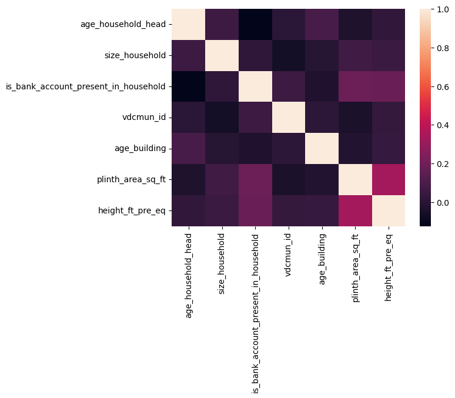

```python
# Create correlation matrix
correlation = df.select_dtypes("number").drop(columns='severe_damage').corr()

# Plot heatmap of `correlation`
sns.heatmap(correlation);
```

### 3.2. Feature vs. Target Analysis

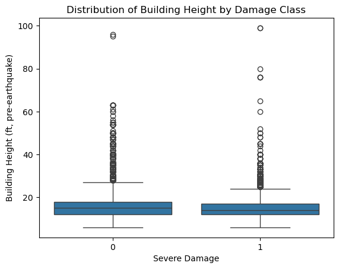

```python
# Create boxplot
sns.boxplot(x='severe_damage' , y='height_ft_pre_eq' , data=df)

# Label axes
plt.xlabel('Severe Damage')
plt.ylabel('Building Height (ft, pre-earthquake)')
plt.title("Distribution of Building Height by Damage Class");
```

### 3.3. Class Balance

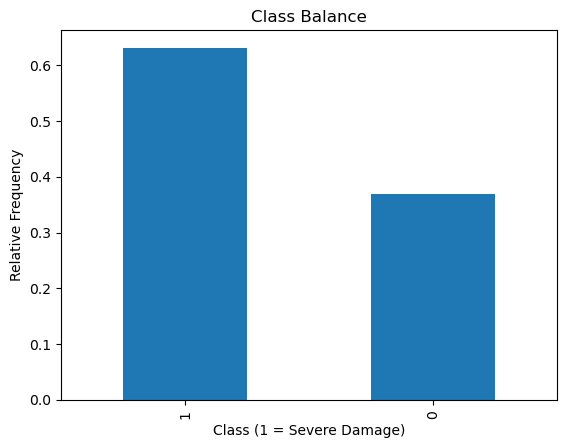

```python
# Plot value counts of `"severe_damage"`
df['severe_damage'].value_counts(normalize=True).plot(
    kind = "bar",xlabel='Class (1 = Severe Damage)',ylabel='Relative Frequency',title='Class Balance'
)
```

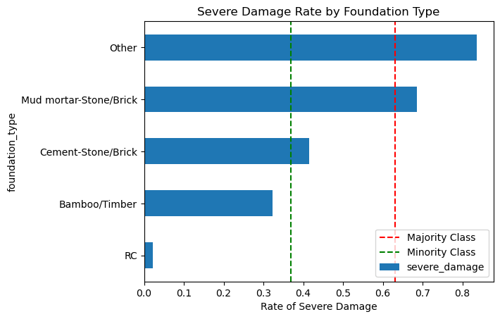

```python
# Create pivot table
foundation_pivot = pd.pivot_table(
    df,index='foundation_type', values='severe_damage', aggfunc=np.mean
).sort_values(by= 'severe_damage')

majority_class_prop, minority_class_prop = df['severe_damage'].value_counts(normalize=True)

# Plot bar chart of `foundation_pivot`
foundation_pivot.plot(kind='barh' , legend = None)
plt.axvline(
    majority_class_prop , linestyle="--" , color = 'red' , label='Majority Class'
)

plt.axvline(
    minority_class_prop , linestyle="--" , color="green" , label='Minority Class'
)
plt.title('Severe Damage Rate by Foundation Type')
plt.xlabel('Rate of Severe Damage')
plt.legend(loc="lower right");
```

## 4. Methodology and Modeling

Our modeling approach involves building two distinct classifiers—Logistic Regression and a Decision Tree—to compare a linear and a non-linear method. For this, we first need to split our data into training, validation, and testing sets.

### 4.1. Data Splitting

We first separate our data into a feature matrix `X` and a target vector `y`. We then perform a two-stage split:

1. An 80/20 split of the entire dataset into a training set (for model building and tuning) and a test set (for final, unbiased evaluation).
2. A further 80/20 split of the training set into a smaller training set and a validation set, which will be used for hyperparameter tuning of the Decision Tree.

```python
# Re-load data without demographic info for this section
def wrangle_structure_only(db_path):
    # Connect to database
    conn = sqlite3.connect(db_path)
    # Construct query
    query = """
        SELECT distinct(i.building_id) AS b_id,
           s.*,
           d.damage_grade
        FROM id_map AS i
        JOIN building_structure AS s ON i.building_id = s.building_id
        JOIN building_damage AS d ON i.building_id = d.building_id
        WHERE district_id = 4
    """
    # Read query results into DataFrame
    df = pd.read_sql(query, conn, index_col="b_id")
    # Identify leaky columns
    drop_cols = [col for col in df.columns if "post_eq" in col]
    # Add high-cardinality / redundant column
    drop_cols.append("building_id")
    # Create binary target column
    df["damage_grade"] = df["damage_grade"].str[-1].astype(int)
    df["severe_damage"] = (df["damage_grade"] > 3).astype(int)
    # Drop old target
    drop_cols.append("damage_grade")
    # Drop multicollinearity column
    drop_cols.append("count_floors_pre_eq")
    # Drop columns
    df.drop(columns=drop_cols, inplace=True)
    return df

df_structure = wrangle_structure_only("nepal.sqlite")

target = "severe_damage"
X = df_structure.drop(columns=target)
y = df_structure[target]
```

```python
X_train, X_test, y_train, y_test = train_test_split(
    X,y,test_size=0.2,random_state=42
)

X_train, X_val, y_train, y_val = train_test_split(
        X_train,y_train,test_size=0.2,random_state=42
)
```

### 4.2. Baseline Accuracy

```python
acc_baseline = y_train.value_counts(normalize=True).max()
print("Baseline Accuracy:", round(acc_baseline, 2))
```

```
Baseline Accuracy: 0.64
```

### 4.3. Model 1: Logistic Regression

Our first model is a Logistic Regression classifier. We use a pipeline to combine a `OneHotEncoder` (for converting categorical features into a numerical format) with the `LogisticRegression` predictor. This ensures that the same transformations are applied consistently to our training and testing data.

```python
# Build model
model_lr_structure = make_pipeline(
    OneHotEncoder(use_cat_names=True),
    LogisticRegression(max_iter=1000)
)
# Fit model to training data
model_lr_structure.fit(X_train,y_train)
```

```
Pipeline(steps=[('onehotencoder',
                 OneHotEncoder(cols=['land_surface_condition',
                                     'foundation_type', 'roof_type',
                                     'ground_floor_type', 'other_floor_type',
                                     'position', 'plan_configuration',
                                     'superstructure'],
                               use_cat_names=True)),
                ('logisticregression', LogisticRegression(max_iter=1000))])
```

#### Evaluation

```python
acc_train = accuracy_score(y_train, model_lr_structure.predict(X_train))
acc_test = model_lr_structure.score(X_test,y_test)

print("Training Accuracy:", round(acc_train, 2))
print("Test Accuracy:", round(acc_test, 2))
```

```
Training Accuracy: 0.71
Test Accuracy: 0.72
```

#### Interpretation

The coefficients of a logistic regression model can be interpreted as odds ratios, which tell us how the odds of severe damage change with a one-unit change in a feature. The plots below show the five features that most increase and decrease the odds of severe damage.

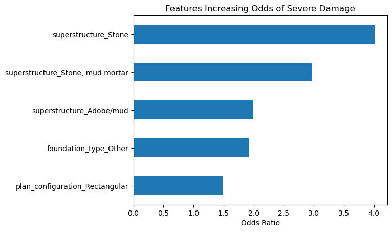

```python
features = model_lr_structure.named_steps["onehotencoder"].get_feature_names()
importances = model_lr_structure.named_steps["logisticregression"].coef_[0]
odds_ratios = pd.Series(np.exp(importances),index=features).sort_values()

# Horizontal bar chart, five largest coefficients
odds_ratios.tail().plot(kind="barh")
plt.xlabel("Odds Ratio");
plt.title('Features Increasing Odds of Severe Damage');
```

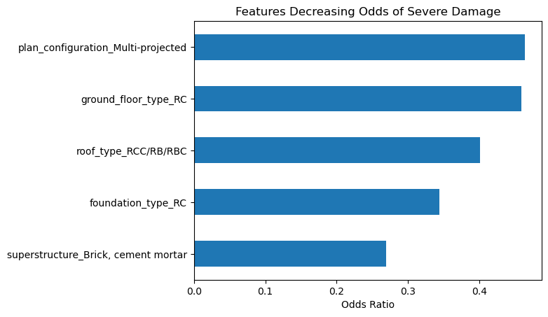

```python
# Horizontal bar chart, five smallest coefficients
odds_ratios.head().plot(kind="barh")
plt.xlabel("Odds Ratio");
plt.title('Features Decreasing Odds of Severe Damage');
```

### 4.4. Model 2: Decision Tree Classifier

Next, we build a Decision Tree model. Unlike linear models, decision trees can capture non-linear relationships between features. We use an `OrdinalEncoder` for categorical features in this pipeline, as tree-based models can handle integer-encoded categories directly.

```python
# Build Model
model_dt_untuned = make_pipeline(
    OrdinalEncoder() , DecisionTreeClassifier(random_state=42)
)
# Fit model to training data
model_dt_untuned.fit(X_train,y_train)
```

```
Pipeline(steps=[('ordinalencoder',
                 OrdinalEncoder(cols=['land_surface_condition',
                                      'foundation_type', 'roof_type',
                                      'ground_floor_type', 'other_floor_type',
                                      'position', 'plan_configuration',
                                      'superstructure'],
                                mapping=[{'col': 'land_surface_condition',
                                          'data_type': dtype('O'),
                                          'mapping': Flat              1
Moderate slope    2
Steep slope       3
NaN              -2
dtype: int64},
                                         {'col': 'foundation_type',
                                          'dat...
E-shape                             7
H-shape                             8
Others                              9
Building with Central Courtyard    10
NaN                                -2
dtype: int64},
                                         {'col': 'superstructure',
                                          'data_type': dtype('O'),
                                          'mapping': Stone, mud mortar        1
Stone                    2
RC, engineered           3
Brick, cement mortar     4
Adobe/mud                5
Timber                   6
RC, non-engineered       7
Brick, mud mortar        8
Stone, cement mortar     9
Bamboo                  10
Other                   11
NaN                     -2
dtype: int64}])),
                ('decisiontreeclassifier',
                 DecisionTreeClassifier(random_state=42))])
```

#### Hyperparameter Tuning

An initial, untuned Decision Tree is highly prone to overfitting. Our first model achieves near-perfect accuracy on the training data but performs much worse on the validation data—a classic sign of overfitting. The tree grew to a depth of 45 levels, learning the training data's noise rather than its underlying signal.

```python
acc_train = accuracy_score(y_train,model_dt_untuned.predict(X_train))
acc_val = model_dt_untuned.score(X_val,y_val)

print("Training Accuracy:", round(acc_train, 2))
print("Validation Accuracy:", round(acc_val, 2))
```

```
Training Accuracy: 0.98
Validation Accuracy: 0.65
```

To combat overfitting, we tune the `max_depth` hyperparameter. We train a series of models with different depths and plot their training and validation accuracy. The goal is to find the depth that maximizes validation accuracy before performance begins to decline or plateau.

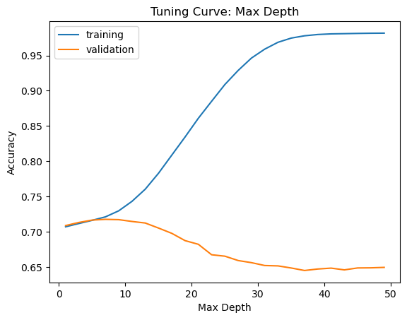

```python
depth_hyperparams = range(1,50,2)
training_acc = []
validation_acc = []

for d in depth_hyperparams:
    test_model = make_pipeline(
        OrdinalEncoder(),
        DecisionTreeClassifier(random_state=42,max_depth=d)
    )
    test_model.fit(X_train, y_train)
    training_acc.append(accuracy_score(y_train,test_model.predict(X_train)))
    validation_acc.append(test_model.score(X_val,y_val))

plt.plot(depth_hyperparams , training_acc,label="training")
plt.plot(depth_hyperparams , validation_acc,label="validation")
plt.xlabel("Max Depth")
plt.ylabel("Accuracy")
plt.title('Tuning Curve: Max Depth')
plt.legend();
```

#### Final Model and Evaluation

```python
# Build Final Model
model_dt_tuned = make_pipeline(
    OrdinalEncoder() , DecisionTreeClassifier(random_state=42 , max_depth=6)
)
# Fit model to all available training data
model_dt_tuned.fit(pd.concat([X_train, X_val]), pd.concat([y_train, y_val]))

test_acc = model_dt_tuned.score(X_test,y_test)
print("Tuned DT Test Accuracy:", round(test_acc, 2))
```

```
Tuned DT Test Accuracy: 0.72
```

#### Interpretation

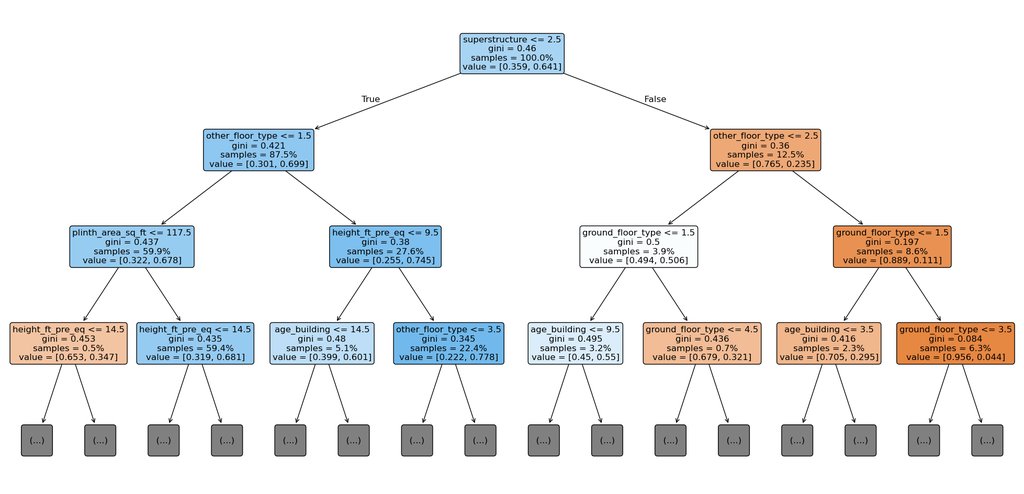

```python
# Create larger figure
fig, ax = plt.subplots(figsize=(25, 12))
# Plot tree
plot_tree(
    decision_tree= model_dt_tuned.named_steps['decisiontreeclassifier'],
    feature_names=X_train.columns.to_list(),
    filled=True,
    rounded=True,
    proportion=True,
    max_depth=3,
    fontsize=12,
    ax=ax,
);
```

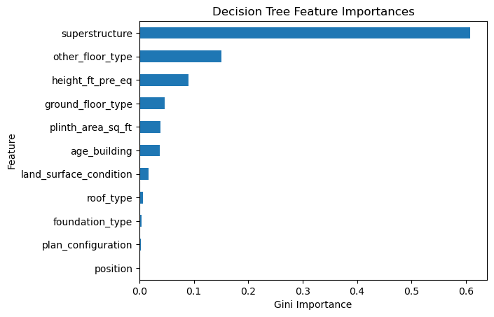

```python
features = X_train.columns
importances = model_dt_tuned.named_steps["decisiontreeclassifier"].feature_importances_
feat_imp = pd.Series(importances, index=features).sort_values()

# Create horizontal bar chart
feat_imp.plot(kind="barh")
plt.xlabel("Gini Importance")
plt.ylabel("Feature");
plt.title('Decision Tree Feature Importances');
```

## 5. Ethical Considerations and Bias Analysis

A model is only as good as the data it's trained on, and real-world data can reflect and amplify societal biases. In this section, we expand our dataset to include household demographic information, specifically the `caste_household` feature, to investigate whether our model's predictions are correlated with sensitive social groups. This is a critical step to ensure that any model deployed for aid allocation does not unfairly disadvantage already vulnerable populations.

### 5.1. Modeling with Demographic Data

We use our comprehensive `wrangle` function to create a new dataset that includes demographic features. We then train a new Logistic Regression model on this enriched data.

```python
df_demographics = wrangle("nepal.sqlite")
target = "severe_damage"
X = df_demographics.drop(columns = [target , "vdcmun_id"])
y = df_demographics[target]

X_train, X_test, y_train, y_test = train_test_split(
    X,y,test_size =0.2 ,random_state=42
)

model_lr = make_pipeline(OneHotEncoder(use_cat_names=True) , LogisticRegression(max_iter=1000))
model_lr.fit(X_train , y_train)
```

```
Pipeline(steps=[('onehotencoder',
                 OneHotEncoder(cols=['gender_household_head', 'caste_household',
                                     'education_level_household_head',
                                     'income_level_household',
                                     'land_surface_condition',
                                     'foundation_type', 'roof_type',
                                     'ground_floor_type', 'other_floor_type',
                                     'position', 'plan_configuration',
                                     'superstructure'],
                               use_cat_names=True)),
                ('logisticregression', LogisticRegression(max_iter=1000))])
```

The model's performance remains consistent, with a test accuracy of 72.3%.

```python
acc_train = model_lr.score(X_train,y_train)
acc_test = model_lr.score(X_test,y_test)

print("LR with Demographics - Training Accuracy:", round(acc_train, 2))
print("LR with Demographics - Test Accuracy:", round(acc_test, 2))
```

```
LR with Demographics - Training Accuracy: 0.72
LR with Demographics - Test Accuracy: 0.72
```

### 5.2. Bias Investigation

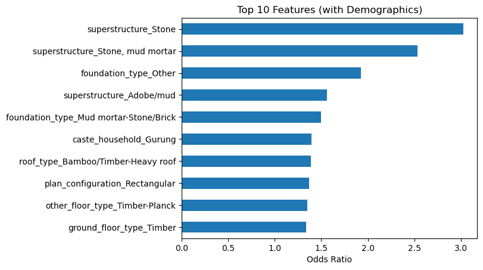

```python
features = model_lr.named_steps["onehotencoder"].get_feature_names()
importances = model_lr.named_steps["logisticregression"].coef_[0]
feat_imp =  pd.Series(np.exp(importances), index=features).sort_values()

feat_imp.tail(10).plot(kind=('barh'))
plt.xlabel('Odds Ratio')
plt.title('Top 10 Features (with Demographics)');
```

### 5.3. Geographical and Demographic Correlation

The visualization below overlays three pieces of information:

1. The rate of severe household damage per municipality (gray line).
2. The proportion of Gurung households in each municipality (blue bars).
3. The proportion of Kumal households in each municipality (orange bars).

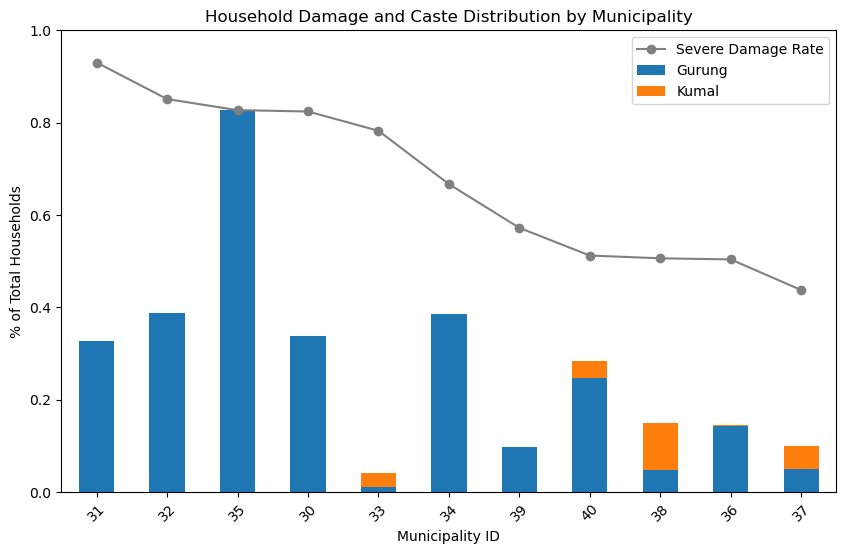

```python
damage_by_vdcmun = (
    df_demographics.groupby("vdcmun_id")["severe_damage"].mean().sort_values(ascending=False)
).to_frame()

damage_by_vdcmun["Gurung"] = (
    df_demographics[df_demographics["caste_household"] == 'Gurung'].groupby("vdcmun_id")["severe_damage"].count()
    / df_demographics.groupby("vdcmun_id")["severe_damage"].count()
)

damage_by_vdcmun["Kumal"] = (
    df_demographics[df_demographics["caste_household"] == 'Kumal'].groupby("vdcmun_id")["severe_damage"].count()
    / df_demographics.groupby("vdcmun_id")["severe_damage"].count()
).fillna(0)

damage_by_vdcmun.drop(columns='severe_damage').plot(kind=("bar") , stacked=True, figsize=(10, 6))
plt.plot(damage_by_vdcmun["severe_damage"].values , color='grey', marker='o', label='Severe Damage Rate')
plt.xticks(ticks=range(len(damage_by_vdcmun)),labels=damage_by_vdcmun.index, rotation=45)
plt.yticks(np.arange(0,1.1,0.2))
plt.xlabel("Municipality ID")
plt.ylabel("% of Total Households")
plt.title("Household Damage and Caste Distribution by Municipality")
plt.legend();
```

## 6. Business Implications and Recommendations

Our findings have significant implications for disaster relief and urban planning in Nepal. The models provide a powerful tool for risk assessment, while the ethical analysis ensures that data-driven strategies are equitable.

## 7. Future Work

This project lays a strong foundation for further work. Potential next steps include:

- **Advanced Modeling:** Employing more complex models like Random Forests or Gradient Boosting Machines could potentially improve predictive accuracy.
- **Expanded Scope:** Applying the same methodology to other districts in Nepal to create a nationwide risk map.
- **Feature Engineering:** Incorporating more granular geographical data, such as proximity to fault lines or soil composition, could further enhance model performance.
- **Deployment:** Developing a simple web application or dashboard to make the model's predictions accessible to policymakers and aid workers in the field.

## 8. Conclusion

This data science project successfully developed and evaluated machine learning models to predict earthquake damage in the Gorkha district of Nepal. We demonstrated that both linear and tree-based models can achieve over 70% accuracy in this complex task. More importantly, we went beyond prediction to conduct a thorough ethical analysis, revealing that specific demographic groups are disproportionately at risk. The true value of this work lies not just in the predictive power of the models, but in their ability to provide actionable, equitable insights that can help protect vulnerable communities and build a more resilient future for Nepal.

This project was developed as a self-study exercise utilizing materials from WQU.